# Trabajo Practico Regresión Avanzada

Modelo Lineal Multivariado

Jose Valdes

2023-07-08

[output not shown]

Se realiza validación de la instalación de los paquetes necesarios para ejecutar el script

```
## [1] TRUE
```

# 2.1. Modelo Aditivo

## Ejercicio 2.1.

Con el set de datos trees, disponible en la biblioteca dplyr de R, pretendemos ajustar un modelo que estimo el volumen (en pies cúbicos) de los árboles de cerezo en función de la longitud de su circunferencia (en pulgadas) y de su altura (en pies).

### a)

Visualizar la asociación entre las variables de a pares.

| Girth | Height | Volume |
| --- | --- | --- |
| 8.3 | 70 | 10.3 |
| 8.6 | 65 | 10.3 |
| 8.8 | 63 | 10.2 |
| 10.5 | 72 | 16.4 |
| 10.7 | 81 | 18.8 |
| 10.8 | 83 | 19.7 |
| 11.0 | 66 | 15.6 |
| 11.0 | 75 | 18.2 |
| 11.1 | 80 | 22.6 |
| 11.2 | 75 | 19.9 |

[output cut: 21 more lines]

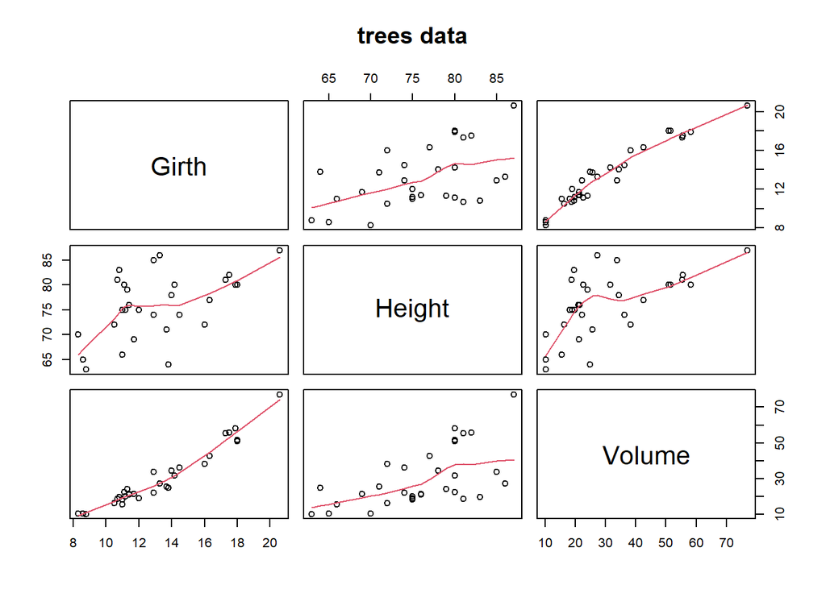

Se observa una relación positiva de las variables.

| Test | HZ | p value | MVN |
| --- | --- | --- | --- |
| Henze-Zirkler | 0.6636803 | 0.127490598 | YES |
| Henze-Zirkler | 1.0912171 | 0.007796525 | NO |
| Henze-Zirkler | 0.9019672 | 0.026926833 | NO |

```
##       cor
## 0.5192801
```

```
##       rho
## 0.9547151
```

```
##       rho
## 0.5787101
```

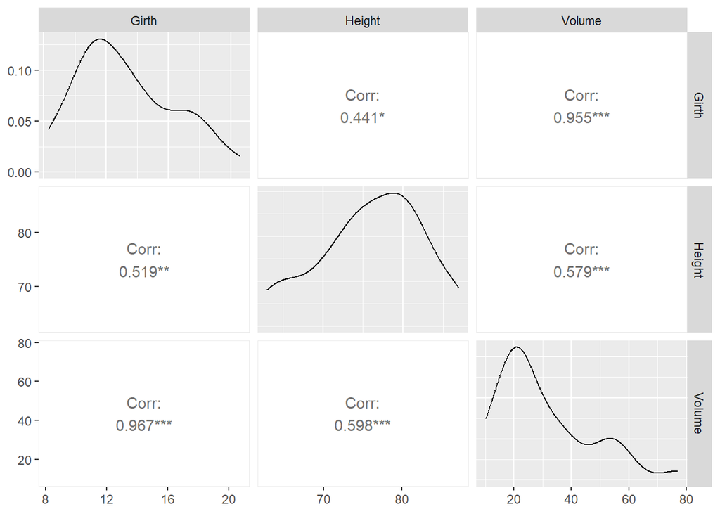

### b)

Ajuste un modelo lineal simple para cada una de las dos predictoras disponibles.

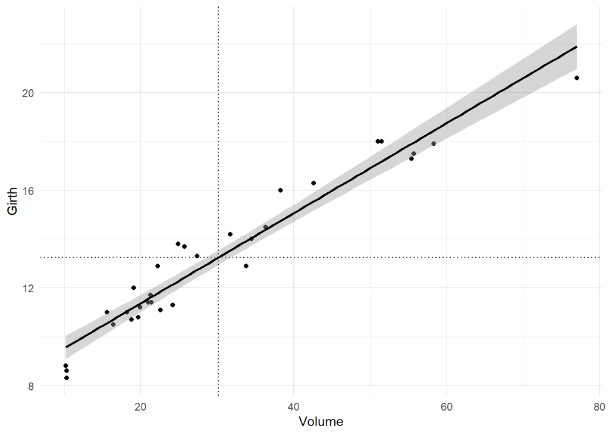

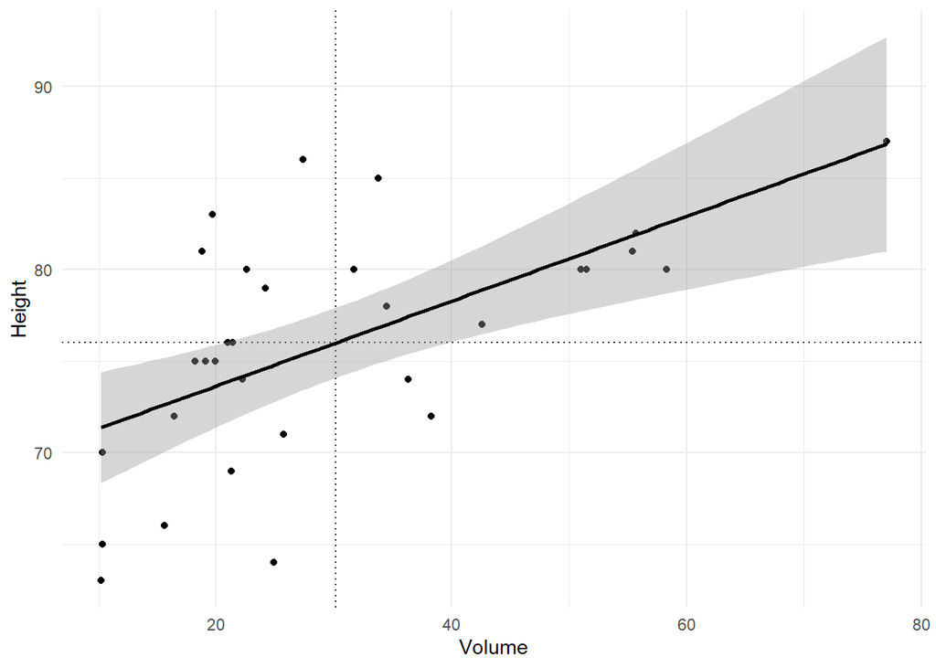

### c)

Realice un análisis diagnóstico en cada caso y señale en caso de haberlos puntos influyentes y outliers.

### d)

Estime un intervalo de confianza para los coeficientes del modelo lineal estimado en cada caso.

### e)

Ajuste un nuevo modelo sin la/s observaciones influyentes.

### f)

Construya el intervalo de confianza y el de predicción del 95% para un árbol cuyo diámetro es 16.1 pulgadas.

### g)

Ajuste un modelo utilizando conjuntamente las dos variables predictoras y compare este ajuste con el mejor de los modelos anteriores mediante un test de modelos anidados. Concluya.

# 2.2. Modelo con Interacción

## Ejercicio 2.2.

# 2.3. Regresoras Categóricas

## Ejercicio 2.3.

# 2.4. Regresión Polinómica

## Ejercicio 2.4.

# 2.5. Modelo Robusto

## Ejercicio 2.6.

# 2.6. Regresión Cuantiles

## Ejercicio 2.7.